# Лабораторная работа №8

Имитационное моделирование

Брыляков Никита Евгеньевич

1132236044@rudn.ru

Российский университет дружбы народов

2026-05-28

## Цель работы

Целью данной лабораторной работы является изучить дискретно-событийный подход к имитационному моделированию на примере классической модели распространения инфекции SIR. Реализовать стохастическую дискретно-событийную модель в виде программного комплекса на языке Julia. Провести анализ влияния параметров, сравнить со стохастической и детерминированной версиями, оценить производительность и модифицировать модель.

## Выполнение лабораторной работы

Предварительно проверим правильность структуры нашего проекта (рис. 1).

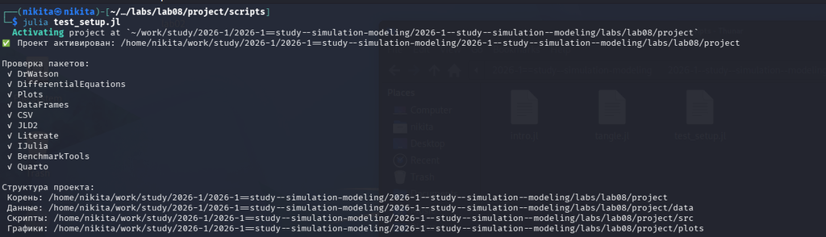

Рисунок 1: Проверка структуры проекта

## Работа с изначальным кодом

Создадим файл src/sir_model.jl с реализацией вычислительной логики модели (рис. 2).

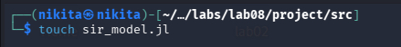

Рисунок 2: Код модели

## Работа с изначальным кодом

Создадим файл scripts/sir_des.jl. Скрипт запуска - он задаёт параметры, инициализирует модель, выполненяет прогон и визуализацию (рис. 3).

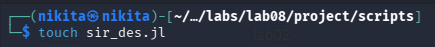

## Работа с изначальным кодом

Запустим скрипт (рис. 4).

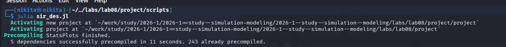

Рисунок 4: Базовый прогон модели

## Работа с изначальным кодом

Создадим производные форматы с помощью скрипта tangle.jl (рис. 5).

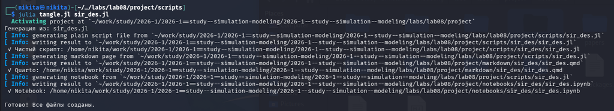

Рисунок 5: Создание производных форматов

## Работа с изначальным кодом

Запустим файл ipynb в jupyter-notebook (рис. 6).

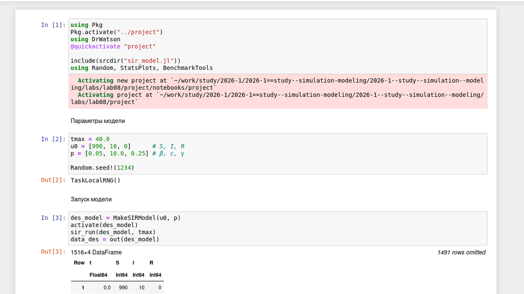

Рисунок 6: Запуск файла в jupyter-notebook

## Работа с изначальным кодом

Просмотрим результирующий график (рис. 7).

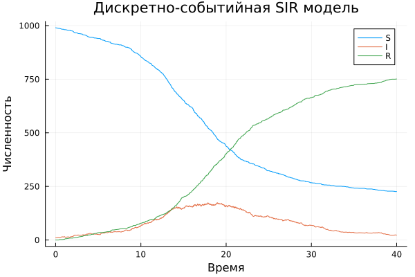

Рисунок 7: sir_des.png

## Внесение изменений

Создаём файлы модели и скрипт запуска (рис. 8).

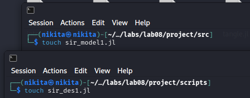

Рисунок 8: Создание файлов

## Внесение изменений

Запустим скрипт (рис. 9).

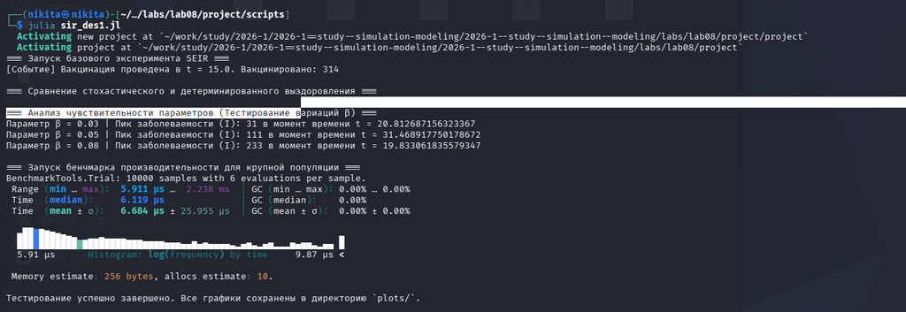

Рисунок 9: Базовый прогон модели

## Внесение изменений

Создадим производные форматы с помощью скрипта tangle.jl (рис. 10).

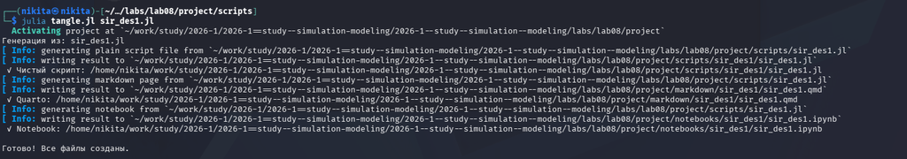

Рисунок 10: Создание производных форматов

## Внесение изменений

Запустим файл ipynb в jupyter-notebook (рис. 11).

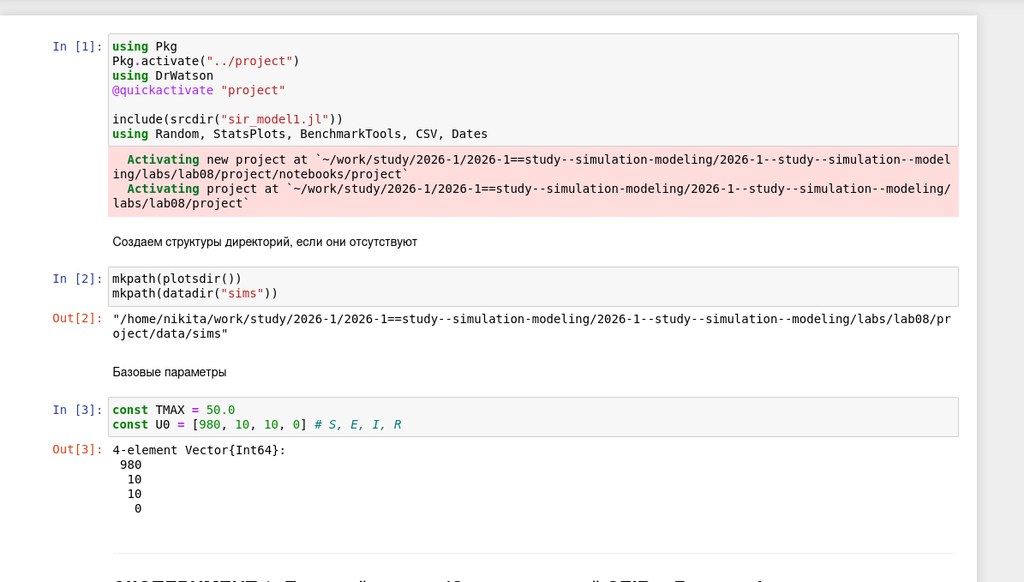

Рисунок 11: Запуск файла в jupyter-notebook

## Внесение изменений

Просмотрим результирующие графики (рис. 12, рис. 13, рис. 14).

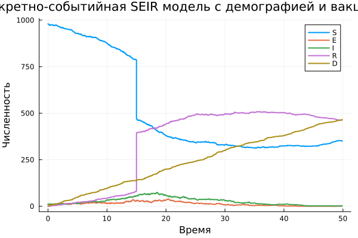

Рисунок 12: seir_base_dynamic.png

## Внесение изменений

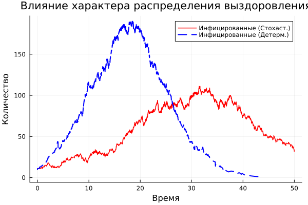

Рисунок 13: seir_recovery_comparison.png

## Внесение изменений

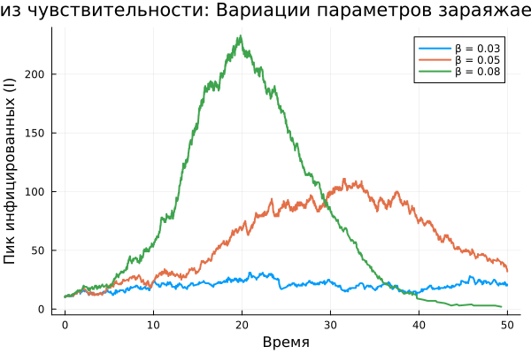

Рисунок 14: seir_sensitivity_analysis.png

## Выводы

В ходе выполнения данной лабораторной работы мной был изучен дискретно-событийный подход к имитационному моделированию на примере классической модели распространения инфекции SIR. Реализована стохастическую дискретно-событийную модель в виде программного комплекса на языке Julia и проведён анализ влияния параметров, сравнение со стохастической и детерминированной версиями, так же проведена оценка производительности и модифицирована модель.